# Trabajo con imágenes

# Aplicación

El objetivo es crear una aplicación donde se muestre como salida la información detallada de cada mamografía.

## Extracción y Limpieza de Imagenes

Extraemos la informacion detallada de cada mamografía del archivo info.txt, posteriormente realizar correccione sobre este para permitir su uso dentro de la app. Al termina lo almacenamos en un .csv para usarlo más adelante en el proyecto.

```r
# Extraer la información detallada de cada mamografía
pacman::p_load(fs, readr, dplyr, furrr, purrr, forcats, stringr, pixmap, png)

# Leer el archivo info.txt con la información detallada de cada mamografía
info <- path("extdata/all-mias/Info.txt") %>%
  # Llevar a cabo algunas correcciones para obtener de forma correcta la información dentro del archivo
  read_delim(delim = " ",
             col_names = c("ref", "bg_tissue", "abnorm", "severity", "x", "y", "approx_radius"),
             col_types = "cccciii",
             skip = 102, n_max = 330)

# Almacenar el resultado en un CSV sin pre-procesar para poder usarlo en las otras fases del proyecto
write_csv(info, file = path("extdata/all-mias/info.csv"))
```

## Pre-precesamiento de datos

Los caracteres son convertidos en factores para ser re-codificados y nos permitan mostrarlos adecuadamente en la app.

```r
# Pre-procesar el resultado para poder usarlo dentro de la app de Shiny
info <- info %>%
  # Convertir los caracteres en factores
  mutate(across(where(is.character), as.factor)) %>%
  # Re-codificar los factores
  mutate(
    bg_tissue = fct_recode(
      bg_tissue,
      "Graso" = "F",
      "Graso-glandular" = "G",
      "Glandular-denso" = "D"
    ),
    abnorm = fct_recode(
      abnorm,
      "Calcificación" = "CALC",
      "Masas bien definidas o circunscritas" = "CIRC",
      "Masa espigada" = "SPIC",
      "Otras masas o mal definidas" = "MISC",
      "Distorsión estructural" = "ARCH",
      "Asimetría" = "ASYM",
      "Normal" = "NORM"
    ),
    severity = fct_recode(
      severity,
      "Benigno" = "B",
      "Maligno" = "M"
    )
  )

# Almacenar el resultado en un archivo RData para su uso dentro de la aplicación
save(info, file = path("app/info.RData"))
```

## Conversión de PGM a PNG

Finalmente realizamos la convesión de las imagenes de su formato original (PGM) a uno que pueda ser visualizado dentro de nuestra app (PNG).

```r
# Función para convertir las imágenes en formato PGM a formato PNG para poder visualizarlas dentro de la aplicación
pnm_to_png <- function(filename, new_filename) {
  # Leer la imagen en formato PGM
  img <- read.pnm(filename)
  # Almacenar la imagen en formato PNG manteniendo sus dimensiones originales
  png(new_filename, width = img@size[1], height = img@size[2])
  plot(img)
  dev.off()
}

# Crear un nuevo directorio para almacenar las imágenes en formato PNG dentro del directorio de la aplicación
dir_create("app/img")

# Obtener la ubicación de cada imagen en formato PGM
img_paths <- dir_ls("extdata/all-mias/", glob = "*.pgm")

# Crear una nueva ubicación para cada imagen en formato PNG
new_img_paths <- path("app/img", str_extract(img_paths, pattern = "(?<=mdb0{0,2})[1-9]{1}[:digit:]{0,2}"), ext = "png")

# Paralelizar la conversión de las imágenes para que el proceso termine más rápido
plan(multisession, workers = 4)

# Convertir las imágenes en formato PGM a formato PNG
future_map2(img_paths, new_img_paths, ~ pnm_to_png(.x, .y))
```

## Demostración de la Aplicación

La aplicación se encuentra divdida en 2 partes.

### Informacón de todas las mamografías

Muestra la información importante de cada imagen como son tejido, anormalidad, diagnóstico y coordenadas de la anormalidad. Se agregaron filtros para facilitar la busqueda de casos especificos.

[figure not shown]

RE

### Informacón por mamografía

Presenta la información disponible de una manera detallada sobre cada imagen de manera individual, contiene la misma informacion que la sección anterior pero sumando la representación visual de la mamografía la cual ayuda a identificar los detalles dentro de la misma

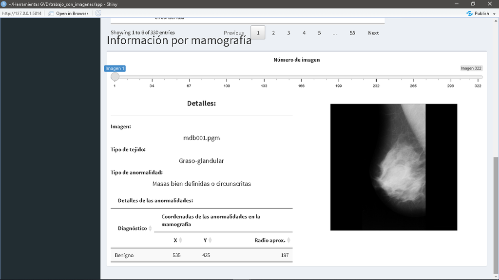

RE

# Limpieza de Imagen

El objetivo es replicar un proceso de limpieza del fondo de la imagen

## Artículos a replicar

Los artículos que usamos como referencia para desarrollar los proyectos son los siguientes:

- *An improved GVF snake based breast region extrapolation scheme for digital mammograms* de *Liu et al*.: El objetivo de este artículo es extrapolar la región del busto usando un esquema mejorado de una serpiente Flujo del Vector Gradiente o *Gradient Vector Flow (GVF) snake*.
- *A pectoral muscle segmentation algorithm for digital mammograms using Otsu thresholding and multiple regression analysis* de *Liu et al*: El objetivo de este artículo es segmentar la región del músculo pectoral de la región del pecho combinando el esquema de umbralización de Otsu y el procesamiento matemático morfológico para obtener un borde del músculo pectoral, y usar el análsis de regresión múltiple (*MRA*) para obtener una segmentación precisa del mismo.

## Primera parte: Extrapolación de la región del busto

Para llevarl a cabo, tomamos como referencia el primer artículo de *Liu et al*. [1] En este artículo, los autores proponen un esquema mejorado de una serpiente Flujo del Vector Gradiente o *Gradient Vector Flow (GVF) snake* para poder extrapolar toda la región del busto. Este esquema o algoritmo que ellos proponen es el siguiente:

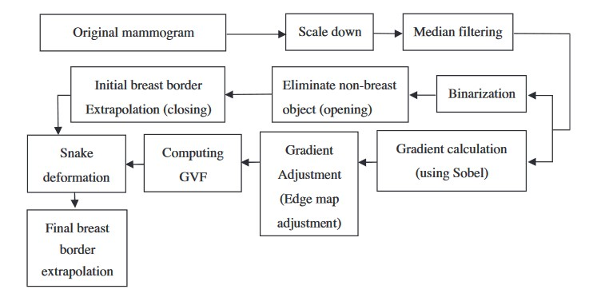

RE

1. Reescalar las imágenes originales de las mamografías.
2. Aplicar un filtro de mediana a las imágenes reescaladas.

En este punto, el proceso se divide en 2 fase:

3. Binarizar la imagen reescalada.
4. Eliminar los objetos que no son de la región del busto.
5. Obtener une extrapolación inicial del borde del busto.

Paralelamente:

3. Aplicar un filtro de Sobel para obtener el campo gradiente de la mamografía reescalada.
4. Ajustar el campo gradiente.
5. Calcular el Flujo del Vector Gradiente (*GVF*).

En este punto, ambos procesos se unen:

6. Aplicar la deformación serpiente usando el *GVF* calculado sobre la extrapolación inicial del borde del busto.
7. Obtener la extrapolación final del borde del busto.

### Tarea 1

#### 2. Replica un proceso de limpieza del fondo de la imagen

Este proceso sigue la primera ramificación del algoritmo propuesto por los autores.

Primero, se importan al entorno todas las imágenes originales.

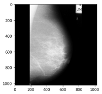

RE

```r
# Ruta de las imágenes originales
base_dir = '../extdata/all-mias/'
all_filenames = os.listdir(base_dir)
imgs_filenames = list()

# Extraer los archivos que corresponden a las imágenes de las mamografías
for filename in all_filenames:
    if filename.endswith('.pgm'):
        imgs_filenames.append(filename)

# Lectura de las imágenes con el parámetro -1 para leer la imagen sin modificar
imgs_orig = list(map(lambda img_name: cv.imread(base_dir+img_name, -1), imgs_filenames))

# Imagen de ejemplo
plt.imshow(imgs_orig[13], cmap='gray')
plt.show()
```

##### 2.1 Reescalar la imagen

Siguiendo el diagrama de flujo propuesto, el primer paso es reescalar la imagen para hacerla más pequeña. Esto permitirá ahorrar tiempo en la ejecución de los pasos.

Para mantener la calidad de la extrapolación, los autores sugieren reescalar las imágenes originales de 1024 x 1024 pixeles a 256 x 256 pixeles.

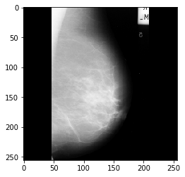

RE

```r
# Reescalar las imágenes para hacerlas más pequeñas (scale down)
imgs_scale = list(map(lambda img_orig: cv.resize(img_orig, (256, 256)), imgs_orig))

# Imagen de ejemplo
plt.imshow(imgs_scale[13], cmap='gray')
plt.show()
```

##### 2.2 Aplicar el filtro de mediana

Los autores sugieren aplicar un filtro de mediana de 3 x 3 pixeles para reducir el ruido de la imagen.

[figure not shown]

RE

```r
# Aplicar un filtro de mediana a cada una de las imágenes
imgs_filter = list(map(lambda img_scale: cv.medianBlur(img_scale, 3), imgs_scale))

# Imagen de ejemplo
plt.imshow(imgs_filter[13], cmap='gray')
plt.show()
```

##### 2.3 Binarización de las imágenes

La fórmula para calcular el umbral $T$ es la siguiente:

$$T = 0.2 \cdot \frac{\sum_{n = 0}^{255} n \cdot H(n)}{\sum_{n = 0}^{255} H(n)}$$

donde $n$ es el valor del nivel de gris, el cual va de 0 a 255, y $H(n)$ es el número de pixeles con el valor de pixel $n$ dentro de la imagen, el cual se obtiene de su histograma.

Para binarizarla, se sigue la siguiente fórmula:

$$IB(x, y) = \begin{cases}
1,\text{ si } I(x,y) \geq T,\\
0, \text{ de otra forma}.
\end{cases}$$

donde $I(x, y)$ es el valor de intensidad de cada pixel en la imagen.

De esta forma, la imagen quedará divida en la región de fondo (con valor de pixel 0) y la región de objetos (con valor de pixel 1).

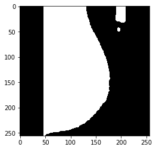

RE

```r
# Obtener del umbral a partir del valor del nivel de gris en la imagen
def T(img):
    H_n = np.histogram(img, bins=256, range=(0, 256))[0]
    return 0.2 * np.sum(np.arange(0, 256) * H_n) / np.sum(H_n)

# Binarizar la imagen
def binarization(img):
    return np.where(img >= T(img), 1, 0).astype(np.uint8)

# Binarización de las imágenes
imgs_bin = list(map(lambda img_filter: binarization(img_filter), imgs_filter))

# Imagen de ejemplo
plt.imshow(imgs_bin[13], cmap='gray')
plt.show()
```

##### 2.4 Eliminar los objetos que no son parte de la región del busto.

Este proceso está compuesto de 2 partes:

###### 2.4.1 Procesamiento morfológico

Tomando como base el ejemplo de la imagen binarizada, se puede notar que además de la región del busto, hay pequeñas regiones que no son de interés. Para eliminarlos, los autores proponen en su algoritmo aplicar la operación morfológica de apertura, la cual está compuesta de 2 transformaciones morfológicas:

- La **erosión**, la cual, como dice su nombre, erosiona los límites del objeto en primer plano (siempre trata de mantener el primer plano en blanco).
- La **dilatación**, que es lo opuesto a la erosión. Esto provoca que aumente la región blanca en la imagen o aumente el tamaño del objeto en primer plano.

Para ello, la función toma un kernel que se desliza por la imagen, y modfica el valor de un pixel de acuerdo con los siguientes criterios:

- En el caso de la **erosión**, el valor del pixel será de 1 solamente si todos los pixeles bajo el kernel son 1. Sino, se erosiona (se vuelve 0).
- En el caso de la **dilatación**, el valor del pixel será de 1 si al menos un pixel bajo el kernel es de 1.

Los autores proponen usar un elemento estructurado (kernel) formado por un disco de radio 2 pixeles.

```r
# Creación del kernel compuesto por un disco de radio 2
kernel = cv.getStructuringElement(cv.MORPH_ELLIPSE, (5, 5))
kernel
```

array([[0, 0, 1, 0, 0],  
[1, 1, 1, 1, 1],  
[1, 1, 1, 1, 1],  
[1, 1, 1, 1, 1],  
[0, 0, 1, 0, 0]], dtype=uint8)

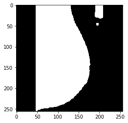

RE

```r
# Aplicar el procesamiento morfológico de apertura sobre las imágenes binarizadas
imgs_mpo = list(map(lambda img_bin: cv.morphologyEx(img_bin, cv.MORPH_OPEN, kernel), imgs_bin))

# Imagen de ejemplo
plt.imshow(imgs_mpo[13], cmap='gray')
plt.show()
```

Aún después de aplicar esta operación, y como se visualiza en la imagen de ejemplo, aún quedan elementos que no corresponden al área del busto. Sin embargo, claramente se puede notar que su tamaño es menor en comparación al área del busto.

Por ello, para eliminar los elementos faltantes, los autores proponen usar las características del objeto busto en la imagen mamográfica para etiquetar los objetos, y después extraer el objeto de mayor tamaño de la imagen binarizada. Y aquellos objetos que no correspondan al área del busto se modifican para volverse parte del fondo en dicha imagen. Finalmente, estos objetos también se modifican en la imagen reducida $I$, estableciendo sus valores de intensidad igual al nivel de gris medio del área que no pertenece al área del busto en $I$.

Sin embargo, los autores no explican cómo llevaron a cabo este proceso. Por lo que nosotros implementamos un proceso que busca replicar los puntos que ellos mencionan.

Este proceso se compone de los siguientes pasos, aplicados a cada mamografía:

1. Obtener los contornos de los objetos en la imagen binarizada ya modificada por el procesamiento morfológico de apertura.
2. Tomar el contorno del objeto más grande, que corresponde a la región del busto.
3. Crear una nueva imagen binarizada pintando solamente la región del objeto más grande.
4. Limpiar la mamografía, estableciendo las intensidades de los objetos que no son parte de la región del busto igual al nivel de gris medio del área que no pertenece al busto, obteniendo dicho valor a partir de la fórmula del umbral T.

```r
# Obtener el contorno del objeto más grande en la imagen binarizada procesada
def get_max_contour(img_mpo):
    _, contours, _ = cv.findContours(img_mpo, cv.RETR_EXTERNAL, cv.CHAIN_APPROX_SIMPLE)
    # Se obtiene el contorno del objeto más grande
    return [max(enumerate(contours), key = lambda tup: len(tup[1]))[1]]

"""Obtener los objetos que no son la región del busto en la
imagen binarizada original"""
def get_non_breast_obj(img_bin):
    _, contours, _ = cv.findContours(img_bin, cv.RETR_EXTERNAL, cv.CHAIN_APPROX_SIMPLE)
    # Se obtiene el índice del contorno del objeto más grande
    ind_max_contour = max(enumerate(contours), key = lambda tup: len(tup[1]))[0]
    # Se elimina el índice del objeto más grande
    del contours[ind_max_contour]
    # Obtener las regiones de estos objetos
    new_img_bin = np.zeros(img_bin.shape).astype(img_bin.dtype)
    cv.fillPoly(new_img_bin, contours, 1)
    return new_img_bin

"""Obtener dos nuevas imágenes binarizadas destacando en ambos casos solamente
el objeto de mayor tamaño (la región del busto)"""
def clean_img_mpo(img_mpo):
    new_img_bin = np.zeros(img_mpo.shape).astype(img_mpo.dtype)
    new_inv_img_bin = np.ones(img_mpo.shape).astype(img_mpo.dtype)
    max_contour = get_max_contour(img_mpo)
    # Obtener la nueva imagen binarizada y su inversa
    cv.fillPoly(new_img_bin, max_contour, 255)
    cv.fillPoly(new_inv_img_bin, max_contour, 0)
    return new_img_bin, new_inv_img_bin

# Obtener una nueva mamografía eliminando los objetos que no son parte de la región del busto
def get_breast_region(img_scale, img_bin, img_mpo):
    # Limpiar la imagen binarizada preprocesada
    new_img_bin, new_inv_img_bin = clean_img_mpo(img_mpo)
    # Obtener las intensidades del área que no pertenece a la región del busto
    non_breasts_obj = img_scale * new_inv_img_bin
    # Calcular el valor de gris medio de estas áreas usando la fórmula del umbral T
    mean_gray_level = T(non_breasts_obj)
    # Modificar las intensidades de estas regiones con este valor
    img_mean_gray_level = mean_gray_level * get_non_breast_obj(img_bin)
    new_img_scale = np.where(img_mean_gray_level == 0, img_scale, img_mean_gray_level)
    return new_img_scale, new_img_bin
```

```r
# Eliminar los objetos que no son parte de la región del busto en las imágenes escaladas
clean_imgs = list()
clean_imgs_bin = list()

for img_scale, img_bin, img_mpo in zip(imgs_scale, imgs_bin, imgs_mpo):
    clean_img, clean_img_bin = get_breast_region(img_scale, img_bin, img_mpo)
    clean_imgs.append(clean_img)
    clean_imgs_bin.append(clean_img_bin)
```

[figure not shown]

RE

```r
# Imagen de ejemplo (Imagen escalada limpia)
plt.imshow(clean_imgs[13], cmap='gray')
plt.show()
```

[figure not shown]

RE

```r
# Imagen de ejemplo (Imagen binarizada limpia)
plt.imshow(clean_imgs_bin[13], cmap='gray')
plt.show()
```

A work by [Fernando Gomez](https://github.com/ferxohn), [Ricardo Vargas](https://github.com/FadenZiehen), [Calvin Lopez](https://github.com/Klvinn)

*160300129@ucaribe.edu.mx*

*170300226@ucaribe.edu.mx*

*170300226@ucaribe.edu.mx*